# Comités

Roles de los miembros de los comites del VICCM

# Comité Científico

Su función es seleccionar las ponencias presentadas. Las ponencias se revisan y seleccionan en función de su excelencia científica. Los integrantes del Comité Científico realizan una selección final de las ponencias científicamente excelentes para crear un programa equilibrado e interesante, que fomente una amplia participación y representación de todos los temas del VICCM.

*Haga clic en las fotos para ver sus detalles y contribuciones.*

[figure not shown]

Hugo Mantilla-Meluk

Aspectos científicos y divulgación

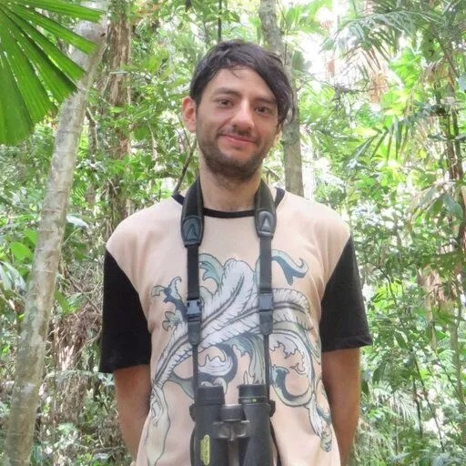

Andres Felipe Suárez-Castro

Comité científico

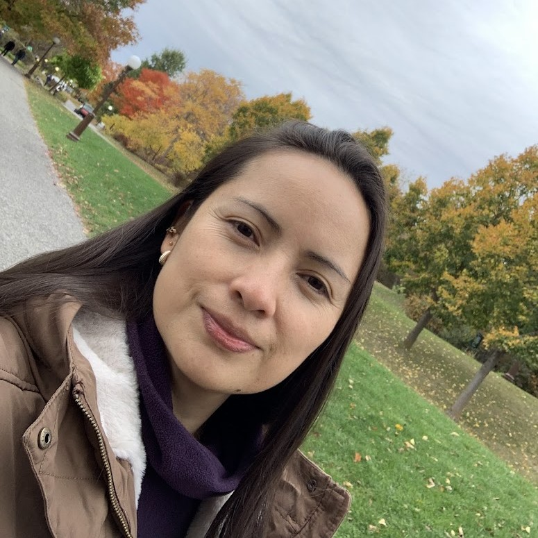

Adriana C. Acero-Murcia

Comité científico

# Comité Organizador

Es responsable de definir el desarrollo a medio y largo plazo de la serie de conferencias y de garantizar que esta mantenga un alto nivel organizativo. El congreso suele tener una duración de una semana (de lunes a viernes) en noviembre 2026.

*Haga clic en las fotos para ver sus detalles y contribuciones.*

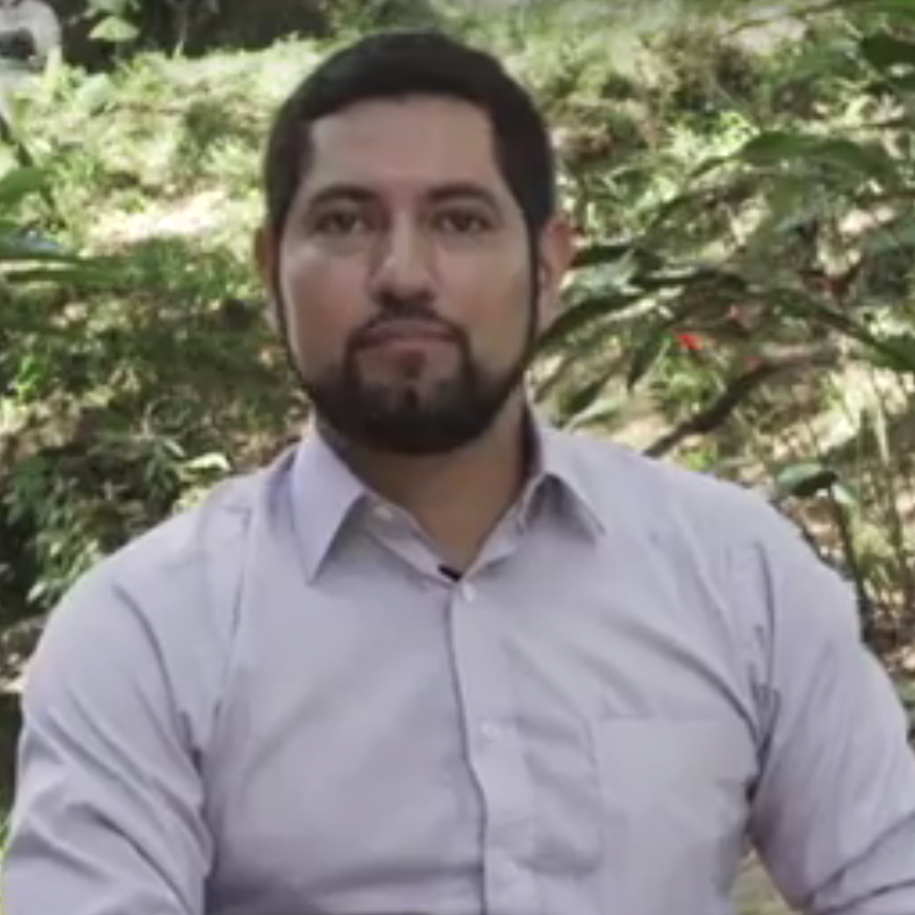

Javier García-Villalba

Organizador

[figure not shown]

Luisa F. Martínez

Comunicaciones y logística

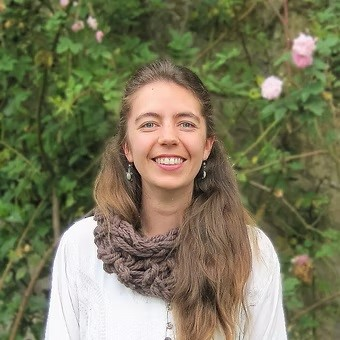

Catalina Concha-Osbahr

Presidenta SCMas

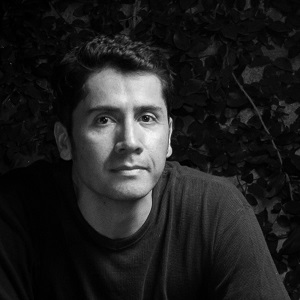

Diego J. Lizcano

Pagina web y OpenConf

El VICCM será posible gracias a la generosa contribucion de los socios de la [SCMas](https://www.mamiferoscolombia.org/La-SCMas/), y es organizado por [La Universidad de la Amazonia](https://www.uniamazonia.edu.co/)

[figure not shown]

[figure not shown]

**Agradecemos a nuestros generosos patrocinadores**

Con sus contribuciones, no solo apoyan esta serie de conferencias, sino también la conservación de la Biodiversidad en Colombia. Si desea convertirse en patrocinador, por favor póngase [en contacto con nosotros acá](https://www.mamiferoscolombia.org/VICCM/contacto/)

This work is licensed under a [Creative Commons Attribution 4.0 License](https://creativecommons.org/licenses/by/4.0/)